# data.table 패키지 소개

yujin

2022 1 6

# 시작하기 전에

본 자료는 빠른 속도와 메모리 효율성에 강점이 있는 **data.table** 패키지에 관해 기본 개념과 문법, 함수들을 예제를 통해 다루어 볼 것이다.

# 1. 개념 소개

**data.table** 패키지는 대용량의 데이터를 분산 처리 시스템 없이 처리할 수 있는 방법으로, 데이터 프레임을 대신하여 더 빠르고 편리하게 사용할 수 있는 데이터 타입이다.

- 장점- 상대적으로 메모리 요구량이 적고, 속도가 매우 빠르다.
- 단점- 다소 난해한 문법으로 널리 사용되지는 못하고 있다.

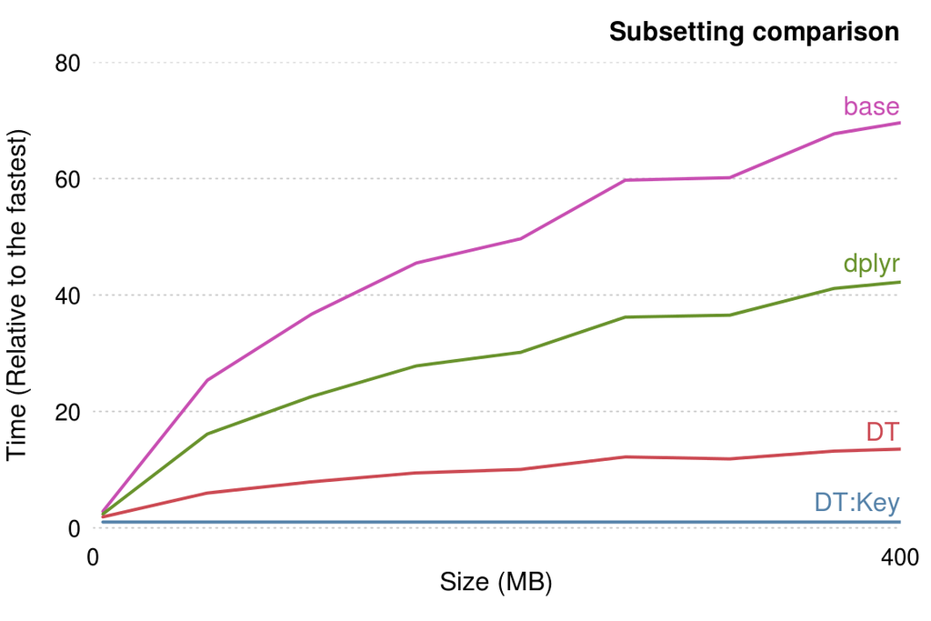

# 2. 기본 문법

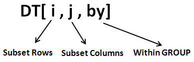

**data.table** 의 기본 문법은 **DT[i, j, by]** 형태이다.

- **i**는 행을 선택하거나 순서를 조정한다.
- **j**는 열을 선택하거나 열 또는 테이블 전체에 함수를 적용한다.
- **by**는 집단을 나눈다. j에서 지정한 열과 함수를 by 그룹 별로 수행한다.
- 뒤에 [order]를 붙여 오름차순이나 내림차순으로 정렬할 수 있다.

## Load & save data: `fread` & `fwrite`

`fread` 함수로 빠르게 csv 파일을 읽어와서 `data.table` 자료로 만들 수 있고, `fwrite` 함수로 csv 파일을 쓸 수 있다. `fread`와 `fwrite` 는 이름답게 매우 빠르며 Base R의 함수보다 40배 더 빠른 속도를 자랑한다. 파일을 읽어와서 `data.table` 자료로 만들 때, 로컬 file path를 입력하거나 http:// 로 시작하는 url을 입력하는 방법을 사용한다. `fread`로 파일을 읽으면 그 class는 `data.frame`에 `data.table`이 추가되며 문법이 원래의 `data.frame`과 달라지는 점을 유의하자.

```r
# install.packages("data.table")
# install.packages("curl")
library(knitr)
library(curl)
library(data.table)
```

```r
# Load file
url <- "https://raw.githubusercontent.com/jinseob2kim/lecture-snuhlab/master/data/example_g1e.csv"
df <- read.table(url,header=T)
dt <- fread(url,header=T)

# Class
print(class(df))
```

```
## [1] "data.frame"
```

```r
print(class(dt))
```

```
## [1] "data.table" "data.frame"
```

dt의 class에 `data.table`이 추가된 것을 볼 수 있다.

```r
#dt = data.table(df)
#df = data.frame(dt)

## See
head(dt)
```

```
##    EXMD_BZ_YYYY RN_INDI HME_YYYYMM Q_PHX_DX_STK Q_PHX_DX_HTDZ Q_PHX_DX_HTN
## 1:         2009  562083     200909            0             0            1
## 2:         2009  334536     200911            0             0            0
## 3:         2009  911867     200903            0             0            0
## 4:         2009  183321     200908           NA            NA           NA
## 5:         2009  942671     200909           NA            NA           NA
## 6:         2009  979358     200912           NA            NA           NA
##    Q_PHX_DX_DM Q_PHX_DX_DLD Q_PHX_DX_PTB Q_HBV_AG Q_SMK_YN Q_DRK_FRQ_V09N HGHT
## 1:           0            0           NA        3        1              0  144
## 2:           0            0           NA        2        1              0  162
## 3:           0            0           NA        3        1              0  163
## 4:          NA           NA           NA        3        1              0  152
## 5:          NA           NA           NA        3        1              0  159
## 6:          NA           NA           NA        2        1              0  157
##    WGHT WSTC  BMI VA_LT VA_RT BP_SYS BP_DIA URN_PROT  HGB FBS TOT_CHOL  TG HDL
## 1:   61   90 29.4   0.7   0.8    120     80        1 12.6 117      264 128  60
## 2:   51   63 19.4   0.8   1.0    120     80        1 13.8  96      169  92  70
## 3:   65   82 24.5   0.7   0.6    130     80        1 15.0 118      216 132  55
## 4:   51   70 22.1   0.8   0.9    101     62        1 13.1  90      199 100  65
## 5:   50   73 19.8   0.7   0.8    132     78        1 13.0  92      162  58  40
## 6:   55   73 22.3   1.5   1.5    110     70        1 11.9 100      192 109  53
##    LDL CRTN SGOT SGPT GGT GFR
## 1: 179  0.9   25   20  25  59
## 2:  80  0.9   18   15  28  74
## 3: 134  0.8   26   30  30  79
## 4: 114  0.9   18   14  11  61
## 5: 111  0.9   24   23  15  49
## 6: 117  0.7   15   12  14  83
```

```r
# Save file
write.csv(dt, "aa.csv",row.names=F)
fwrite(dt, "aa.csv")
```

## row operation

행을 선택하는 slice는 `data.table`에서 **DT[c(row1, row2, …),]** 또는 **DT[c(row1, row2, …)]**의 형식으로 `data.frame`과 동일하게 쓰인다.

```r
dt[c(3,5)]
```

```
##    EXMD_BZ_YYYY RN_INDI HME_YYYYMM Q_PHX_DX_STK Q_PHX_DX_HTDZ Q_PHX_DX_HTN
## 1:         2009  911867     200903            0             0            0
## 2:         2009  942671     200909           NA            NA           NA
##    Q_PHX_DX_DM Q_PHX_DX_DLD Q_PHX_DX_PTB Q_HBV_AG Q_SMK_YN Q_DRK_FRQ_V09N HGHT
## 1:           0            0           NA        3        1              0  163
## 2:          NA           NA           NA        3        1              0  159
##    WGHT WSTC  BMI VA_LT VA_RT BP_SYS BP_DIA URN_PROT HGB FBS TOT_CHOL  TG HDL
## 1:   65   82 24.5   0.7   0.6    130     80        1  15 118      216 132  55
## 2:   50   73 19.8   0.7   0.8    132     78        1  13  92      162  58  40
##    LDL CRTN SGOT SGPT GGT GFR
## 1: 134  0.8   26   30  30  79
## 2: 111  0.9   24   23  15  49
```

특정한 조건을 만족하는 행을 선택하는 filter는 `data.table`에서 **DT[cond,]**의 형식으로 쓰인다.

(이때, cond는 논리형 벡터이다.)

```r
dt[BMI>=30 & HGHT<150]
```

```
##    EXMD_BZ_YYYY RN_INDI HME_YYYYMM Q_PHX_DX_STK Q_PHX_DX_HTDZ Q_PHX_DX_HTN
## 1:         2011  914987     201103            0             0            1
## 2:         2012  803990     201209           NA            NA           NA
## 3:         2014  149142     201412            0             0            0
##    Q_PHX_DX_DM Q_PHX_DX_DLD Q_PHX_DX_PTB Q_HBV_AG Q_SMK_YN Q_DRK_FRQ_V09N HGHT
## 1:           0            0            0        3        1              2  145
## 2:          NA           NA           NA        2        1              0  147
## 3:           0            0            0        2        3              0  149
##    WGHT WSTC  BMI VA_LT VA_RT BP_SYS BP_DIA URN_PROT  HGB FBS TOT_CHOL  TG HDL
## 1:   70   95 33.3   0.5   0.5    130     69        1  8.0 107      183 104  54
## 2:   65   87 30.1   0.2   0.5    154     83        3 12.4 100      234  81  77
## 3:   73  100 32.9   0.6   0.6    130     80        1 13.0  94      232 125  42
##    LDL CRTN SGOT SGPT GGT GFR
## 1: 108  0.9   22   17  33  NA
## 2: 140  0.7   23   19  46  90
## 3: 165  0.9   22   15  22  67
```

미리 key들을 지정하면 더 빠르게 검색할 수 있다. 자세한 내용은 뒤에서 다루도록 하겠다.

## column operation

열을 이름 또는 순번으로 선택하는 select는 **DT[, .(cols)]** 또는 **DT[, .(col1, col2)]**의 형식으로 `data.frame`과 비슷하나 몇 가지 차이점이 있다.

- 순번으로 열 선택

```r
dt[, c(13, 14)]
```

```
##       HGHT WGHT
##    1:  144   61
##    2:  162   51
##    3:  163   65
##    4:  152   51
##    5:  159   50
##   ---
## 1640:  171   76
## 1641:  179   80
## 1642:  163   63
## 1643:  165   70
## 1644:  168   84
```

- 이름으로 열 선택

```r
dt[, .(HGHT, WGHT)]
```

```
##       HGHT WGHT
##    1:  144   61
##    2:  162   51
##    3:  163   65
##    4:  152   51
##    5:  159   50
##   ---
## 1640:  171   76
## 1641:  179   80
## 1642:  163   63
## 1643:  165   70
## 1644:  168   84
```

- 변수로 열 선택

```r
# same
vars <- c(13,14)
vars <- c("HGHT", "WGHT")
dt[, ..vars]
```

```
##       HGHT WGHT
##    1:  144   61
##    2:  162   51
##    3:  163   65
##    4:  152   51
##    5:  159   50
##   ---
## 1640:  171   76
## 1641:  179   80
## 1642:  163   63
## 1643:  165   70
## 1644:  168   84
```

변수 앞에 **..**을 붙이지 않으면 오류가 발생하므로 주의하도록 한다. **..** 대신 with = F 를 뒤에 붙이거나 .SD, .SDcols 옵션을 사용하기도 한다. .SD는 뒤에서 더 자세히 다루도록 하겠다.

```r
dt[, vars, with = F]
```

```
##       HGHT WGHT
##    1:  144   61
##    2:  162   51
##    3:  163   65
##    4:  152   51
##    5:  159   50
##   ---
## 1640:  171   76
## 1641:  179   80
## 1642:  163   63
## 1643:  165   70
## 1644:  168   84
```

- 열 제외

필요없는 열을 제외할 때는 **-** 또는 **!** 를 붙인다.

```r
icols = c(1:12)
dt[, -..icols]
```

```
##       HGHT WGHT WSTC  BMI VA_LT VA_RT BP_SYS BP_DIA URN_PROT  HGB FBS TOT_CHOL
##    1:  144   61   90 29.4   0.7   0.8    120     80        1 12.6 117      264
##    2:  162   51   63 19.4   0.8   1.0    120     80        1 13.8  96      169
##    3:  163   65   82 24.5   0.7   0.6    130     80        1 15.0 118      216
##    4:  152   51   70 22.1   0.8   0.9    101     62        1 13.1  90      199
##    5:  159   50   73 19.8   0.7   0.8    132     78        1 13.0  92      162
##   ---
## 1640:  171   76   88 26.0   1.2   1.2    125     89        1 14.1  77      363
## 1641:  179   80   88 25.0   1.0   0.7    126     83        1 14.9 119      106
## 1642:  163   63   80 23.7   1.5   1.5    118     77        1 16.1 160      271
## 1643:  165   70   92 25.7   0.6   0.8    120     80        1 13.6  81      289
## 1644:  168   84  103 29.8   0.9   0.8    140     85        1 15.2 134      210
##        TG HDL LDL CRTN SGOT SGPT GGT GFR
##    1: 128  60 179  0.9   25   20  25  59
##    2:  92  70  80  0.9   18   15  28  74
##    3: 132  55 134  0.8   26   30  30  79
##    4: 100  65 114  0.9   18   14  11  61
##    5:  58  40 111  0.9   24   23  15  49
##   ---
## 1640: 280  63 244  0.9   19   32  95  96
## 1641: 247  29  50  0.9  101  157  62  79
## 1642: 514  51 151  1.0   40   66 104  85
## 1643: 810  52  NA  1.0   37   33  76  86
## 1644: 298  56  94  1.1   55   49  66  66
```

```r
dt[, !..icols]
```

```
##       HGHT WGHT WSTC  BMI VA_LT VA_RT BP_SYS BP_DIA URN_PROT  HGB FBS TOT_CHOL
##    1:  144   61   90 29.4   0.7   0.8    120     80        1 12.6 117      264
##    2:  162   51   63 19.4   0.8   1.0    120     80        1 13.8  96      169
##    3:  163   65   82 24.5   0.7   0.6    130     80        1 15.0 118      216
##    4:  152   51   70 22.1   0.8   0.9    101     62        1 13.1  90      199
##    5:  159   50   73 19.8   0.7   0.8    132     78        1 13.0  92      162
##   ---
## 1640:  171   76   88 26.0   1.2   1.2    125     89        1 14.1  77      363
## 1641:  179   80   88 25.0   1.0   0.7    126     83        1 14.9 119      106
## 1642:  163   63   80 23.7   1.5   1.5    118     77        1 16.1 160      271
## 1643:  165   70   92 25.7   0.6   0.8    120     80        1 13.6  81      289
## 1644:  168   84  103 29.8   0.9   0.8    140     85        1 15.2 134      210
##        TG HDL LDL CRTN SGOT SGPT GGT GFR
##    1: 128  60 179  0.9   25   20  25  59
##    2:  92  70  80  0.9   18   15  28  74
##    3: 132  55 134  0.8   26   30  30  79
##    4: 100  65 114  0.9   18   14  11  61
##    5:  58  40 111  0.9   24   23  15  49
##   ---
## 1640: 280  63 244  0.9   19   32  95  96
## 1641: 247  29  50  0.9  101  157  62  79
## 1642: 514  51 151  1.0   40   66 104  85
## 1643: 810  52  NA  1.0   37   33  76  86
## 1644: 298  56  94  1.1   55   49  66  66
```

## by operation

by 옵션을 이용하여 그룹별로 함수를 적용할 수 있다. **by=.(그룹1, 그룹2, …)**을 사용해 두 개 이상의 그룹별로 함수를 적용할 수도 있다. 이때 괄호 앞에 있는 점(‘.’)은 list()를 의미하므로 꼭 포함시키도록 한다. by 대신 keyby를 사용할 경우, 그룹별 집계 결과가 정렬되어 나타난다.

년도 변수인 EXMD_BZ_YYYY을 기준으로 집단을 분리한 후 각 집단의 HGHT와 WGHT, BMI 평균을 구하는 방법은 다음과 같다.

```r
dt[, .(HGHT=mean(HGHT), WGHT=mean(WGHT), BMI=mean(BMI)), by=EXMD_BZ_YYYY]
```

```
##    EXMD_BZ_YYYY     HGHT     WGHT      BMI
## 1:         2009 164.0841 64.32710 23.76402
## 2:         2010 164.9280 65.13983 23.82712
## 3:         2011 164.1480 64.89686 23.96009
## 4:         2012 164.9188 65.82051 24.08932
## 5:         2013 164.9095 64.90535 23.75391
## 6:         2014 164.3189 64.47244 23.78031
## 7:         2015 164.4792 66.07500 24.28167
```

기준으로 사용되지 않은 모든 열에 대해 평균을 구한다면 다음과 같다.

```r
dt[, lapply(.SD, mean), by=EXMD_BZ_YYYY]
```

```
##    EXMD_BZ_YYYY  RN_INDI HME_YYYYMM Q_PHX_DX_STK Q_PHX_DX_HTDZ Q_PHX_DX_HTN
## 1:         2009 499606.8   200908.2           NA            NA           NA
## 2:         2010 472277.1   201007.6           NA            NA           NA
## 3:         2011 510926.9   201107.8           NA            NA           NA
## 4:         2012 490263.9   201207.8           NA            NA           NA
## 5:         2013 483700.7   201308.1           NA            NA           NA
## 6:         2014 489703.6   201407.9           NA            NA           NA
## 7:         2015 491209.6   201508.7           NA            NA           NA
##    Q_PHX_DX_DM Q_PHX_DX_DLD Q_PHX_DX_PTB Q_HBV_AG Q_SMK_YN Q_DRK_FRQ_V09N
## 1:          NA           NA           NA       NA       NA             NA
## 2:          NA           NA           NA 2.326271 1.703390      1.0423729
## 3:          NA           NA           NA 2.233184 1.587444      1.0493274
## 4:          NA           NA           NA 2.213675 1.598291      0.9786325
## 5:          NA           NA           NA 2.226337 1.695473             NA
## 6:          NA           NA           NA 2.185039 1.614173             NA
```

[output cut: 25 more lines]

그룹별로 함수를 적용한 결과를 정렬하고자 할 때는 마지막에 **[order()]**를 붙인다.

```r
# BMI에 대해 정렬
dt[, .(HGHT=mean(HGHT), WGHT=mean(WGHT), BMI=mean(BMI)), by=EXMD_BZ_YYYY] [order(BMI)]
```

```
##    EXMD_BZ_YYYY     HGHT     WGHT      BMI
## 1:         2013 164.9095 64.90535 23.75391
## 2:         2009 164.0841 64.32710 23.76402
## 3:         2014 164.3189 64.47244 23.78031
## 4:         2010 164.9280 65.13983 23.82712
## 5:         2011 164.1480 64.89686 23.96009
## 6:         2012 164.9188 65.82051 24.08932
## 7:         2015 164.4792 66.07500 24.28167
```

# 3. functions

- key를 이용한 탐색 setkey()
- 데이터 테이블 병합(merge)
- 데이터 테이블 수정 연산자 :=
- 특수 기호 .SD , .SDcols, .N
- 데이터 재구조화 melt & dcast

## key를 이용한 탐색 setkey()

key를 사용하면 데이터의 탐색 및 처리 속도가 매우 향상된다. **setkey(DT, col)**로 키를 설정하며 키가 문자열 벡터일 경우 **setkeyv**을 활용한다. 설정되어 있는 키를 제거할 때는 setkey(DT, NULL)를 설정한다.

- 키 설정

`setkey`를 활용해 데이터 테이블에 키를 설정하고, `key` 함수로 설정된 키를 확인할 수 있다.

```r
# 1 key
setkey(dt, EXMD_BZ_YYYY)
key(dt)
```

```
## [1] "EXMD_BZ_YYYY"
```

- 키를 활용한 행 선택

**dt[.(a)], dt[J(a)], dt[list(a)], dt[col == a]** 중에서 아무거나 사용하여 행을 선택할 수 있다.

```r
## same

# dt[.(2011)]
# dt[list(2011)]
# dt[EXMD_BZ_YYYY==2011]
dt[J(2011)]
```

```
##      EXMD_BZ_YYYY RN_INDI HME_YYYYMM Q_PHX_DX_STK Q_PHX_DX_HTDZ Q_PHX_DX_HTN
##   1:         2011  562083     201111            0             0            1
##   2:         2011  403607     201107           NA            NA           NA
##   3:         2011  917270     201107            0             0            1
##   4:         2011  831349     201108           NA            NA           NA
##   5:         2011  900114     201112            0             0            0
##  ---
## 219:         2011  908152     201109            0             0            0
## 220:         2011  670343     201105           NA            NA           NA
## 221:         2011  550255     201104            0             0            0
## 222:         2011  720080     201110           NA            NA           NA
## 223:         2011  921924     201112           NA            NA           NA
##      Q_PHX_DX_DM Q_PHX_DX_DLD Q_PHX_DX_PTB Q_HBV_AG Q_SMK_YN Q_DRK_FRQ_V09N
##   1:           0            0            0        2        1              0
##   2:          NA           NA           NA        2        1              0
```

[output cut: 33 more lines]

```r
# 2 keys
setkey(dt, EXMD_BZ_YYYY, Q_HBV_AG)
key(dt)
```

```
## [1] "EXMD_BZ_YYYY" "Q_HBV_AG"
```

```r
## same

# dt[.(2011, 2)]
# dt[list(2011, 2)]
# dt[EXMD_BZ_YYYY==2011 & Q_HBV_AG==2]
dt[J(2011, 2)]
```

```
##      EXMD_BZ_YYYY RN_INDI HME_YYYYMM Q_PHX_DX_STK Q_PHX_DX_HTDZ Q_PHX_DX_HTN
##   1:         2011  562083     201111            0             0            1
##   2:         2011  403607     201107           NA            NA           NA
##   3:         2011  917270     201107            0             0            1
##   4:         2011  831349     201108           NA            NA           NA
##   5:         2011  900114     201112            0             0            0
##  ---
## 143:         2011  798472     201111            0             0            0
## 144:         2011  908152     201109            0             0            0
## 145:         2011  670343     201105           NA            NA           NA
## 146:         2011  550255     201104            0             0            0
## 147:         2011  720080     201110           NA            NA           NA
##      Q_PHX_DX_DM Q_PHX_DX_DLD Q_PHX_DX_PTB Q_HBV_AG Q_SMK_YN Q_DRK_FRQ_V09N
##   1:           0            0            0        2        1              0
##   2:          NA           NA           NA        2        1              0
```

[output cut: 33 more lines]

## 데이터 테이블 병합 merge()

`data.table`은 **key**를 사용하거나, **on=**을 활용하여 두 데이터 데이블을 병합할 수 있다.

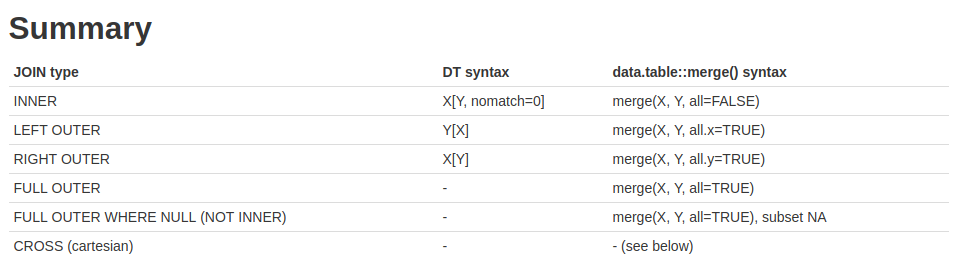

Merge in data.table

### **1. inner join**

두 데이터에 모두 존재하는 경우 **dt1[dt2, on=‘key’, nomatch=0]** 또는 **merge(dt1, dt2, by=‘key’, all=F)** 형식 사용

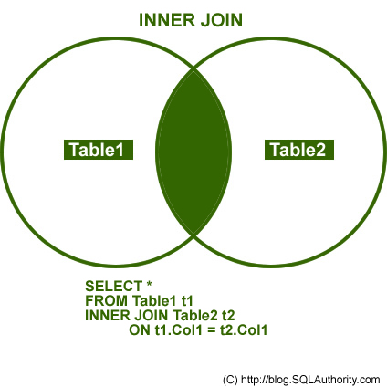

기존의 데이터를 가공하여 새로운 data.table인 **dt1**과 **dt2**에 저장하고 년도에 따라 merge해 보자.

```r
(dt1 <- dt[c(1, 300, 500, 700, 1000)])
```

```
##    EXMD_BZ_YYYY RN_INDI HME_YYYYMM Q_PHX_DX_STK Q_PHX_DX_HTDZ Q_PHX_DX_HTN
## 1:         2009  825387     200904            0             0            0
## 2:         2010  752067     201007            0             0            0
## 3:         2011  694083     201103           NA            NA           NA
## 4:         2012  699142     201210           NA            NA           NA
## 5:         2013  203606     201307            0             0            0
##    Q_PHX_DX_DM Q_PHX_DX_DLD Q_PHX_DX_PTB Q_HBV_AG Q_SMK_YN Q_DRK_FRQ_V09N HGHT
## 1:           0            0           NA       NA        1              1  166
## 2:           0            0            0        2        1              1  167
## 3:          NA           NA           NA        2        1              0  156
## 4:          NA           NA           NA        2        1              0  162
## 5:           0            0            0        2        1              0  153
##    WGHT WSTC  BMI VA_LT VA_RT BP_SYS BP_DIA URN_PROT  HGB FBS TOT_CHOL  TG HDL
## 1:   70   85 25.4   0.9   1.0    130     90        1 14.8 101      193 120  45
## 2:   71   88 25.5   1.0   1.5    116     72        1 13.7  91      207  76  49
## 3:   64   87 26.3   0.3   0.4    136     60        1 14.0  82      195  99  51
## 4:   50   67 19.1   1.5   1.5     96     56        1 12.9  83      150  95  58
## 5:   52   74 22.2   0.8   0.9    118     70        1 12.4 110      175  41  76
##    LDL CRTN SGOT SGPT GGT GFR
## 1: 124  1.0   23   23  18 101
## 2: 143  0.8   19   10  25  NA
## 3: 124  0.7   15   19  15  NA
## 4:  73  0.6   29   28  14 106
## 5:  91  0.8   16   12  20  82
```

```r
(dt2 <- dt[c(400, 600, 800 ,1200, 1500)])
```

```
##    EXMD_BZ_YYYY RN_INDI HME_YYYYMM Q_PHX_DX_STK Q_PHX_DX_HTDZ Q_PHX_DX_HTN
## 1:         2010  548365     201010           NA            NA           NA
## 2:         2011  432825     201112           NA            NA           NA
## 3:         2012  637115     201210            0             0            0
## 4:         2014  437139     201412            0             1            1
## 5:         2015  390119     201506            0             0            0
##    Q_PHX_DX_DM Q_PHX_DX_DLD Q_PHX_DX_PTB Q_HBV_AG Q_SMK_YN Q_DRK_FRQ_V09N HGHT
## 1:          NA           NA           NA        3        1              1  172
## 2:          NA           NA           NA        2        3              5  167
## 3:           0            0            0        2        2              0  165
## 4:           0            1            0        2        1              0  156
## 5:           0            0            0        2        1              4  163
##    WGHT WSTC  BMI VA_LT VA_RT BP_SYS BP_DIA URN_PROT  HGB FBS TOT_CHOL  TG HDL
## 1:   71   82 24.0   1.2   1.0    124     76        1 16.8  92      226 172  63
## 2:   73  105 26.2   1.2   1.5    157    101        1 13.9 114      154 216  48
## 3:   63   81 23.1   0.5   0.6    140     90        1 15.7 112      212 167  51
## 4:   71   93 29.2   1.2   1.2    130     70        1 13.1  87      128  67  57
## 5:   63   84 23.7   1.0   1.0    100     60        1 14.0 116      211 109  65
##    LDL CRTN SGOT SGPT GGT GFR
## 1: 128  0.8   53   67  40  NA
## 2:  62  1.0   21   27  28  NA
## 3: 128  1.0   21   21  40  82
## 4:  57  0.7   20   24   9  90
## 5: 125  0.8   36   44  34 112
```

```r
setkey(dt1, EXMD_BZ_YYYY)
setkey(dt2, EXMD_BZ_YYYY)
```

```r
dt1[dt2, on="EXMD_BZ_YYYY", nomatch=0]
```

```
##    EXMD_BZ_YYYY RN_INDI HME_YYYYMM Q_PHX_DX_STK Q_PHX_DX_HTDZ Q_PHX_DX_HTN
## 1:         2010  752067     201007            0             0            0
## 2:         2011  694083     201103           NA            NA           NA
## 3:         2012  699142     201210           NA            NA           NA
##    Q_PHX_DX_DM Q_PHX_DX_DLD Q_PHX_DX_PTB Q_HBV_AG Q_SMK_YN Q_DRK_FRQ_V09N HGHT
## 1:           0            0            0        2        1              1  167
## 2:          NA           NA           NA        2        1              0  156
## 3:          NA           NA           NA        2        1              0  162
##    WGHT WSTC  BMI VA_LT VA_RT BP_SYS BP_DIA URN_PROT  HGB FBS TOT_CHOL TG HDL
## 1:   71   88 25.5   1.0   1.5    116     72        1 13.7  91      207 76  49
## 2:   64   87 26.3   0.3   0.4    136     60        1 14.0  82      195 99  51
## 3:   50   67 19.1   1.5   1.5     96     56        1 12.9  83      150 95  58
##    LDL CRTN SGOT SGPT GGT GFR i.RN_INDI i.HME_YYYYMM i.Q_PHX_DX_STK
## 1: 143  0.8   19   10  25  NA    548365       201010             NA
## 2: 124  0.7   15   19  15  NA    432825       201112             NA
```

[output cut: 17 more lines]

```r
# same
merge(dt1, dt2, by='EXMD_BZ_YYYY', all = F)
```

```
##    EXMD_BZ_YYYY RN_INDI.x HME_YYYYMM.x Q_PHX_DX_STK.x Q_PHX_DX_HTDZ.x
## 1:         2010    752067       201007              0               0
## 2:         2011    694083       201103             NA              NA
## 3:         2012    699142       201210             NA              NA
##    Q_PHX_DX_HTN.x Q_PHX_DX_DM.x Q_PHX_DX_DLD.x Q_PHX_DX_PTB.x Q_HBV_AG.x
## 1:              0             0              0              0          2
## 2:             NA            NA             NA             NA          2
## 3:             NA            NA             NA             NA          2
##    Q_SMK_YN.x Q_DRK_FRQ_V09N.x HGHT.x WGHT.x WSTC.x BMI.x VA_LT.x VA_RT.x
## 1:          1                1    167     71     88  25.5     1.0     1.5
## 2:          1                0    156     64     87  26.3     0.3     0.4
## 3:          1                0    162     50     67  19.1     1.5     1.5
##    BP_SYS.x BP_DIA.x URN_PROT.x HGB.x FBS.x TOT_CHOL.x TG.x HDL.x LDL.x CRTN.x
## 1:      116       72          1  13.7    91        207   76    49   143    0.8
## 2:      136       60          1  14.0    82        195   99    51   124    0.7
```

[output cut: 21 more lines]

### **2. left_outer_join**

첫 번째 데이터에 존재하는 경우 **dt2[dt1, on=‘key’]** 또는 **merge(dt1, dt2, by=‘key’, all.x=T)** 형식 사용

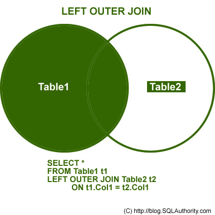

```r
dt2[dt1, on='EXMD_BZ_YYYY']
```

```
##    EXMD_BZ_YYYY RN_INDI HME_YYYYMM Q_PHX_DX_STK Q_PHX_DX_HTDZ Q_PHX_DX_HTN
## 1:         2009      NA         NA           NA            NA           NA
## 2:         2010  548365     201010           NA            NA           NA
## 3:         2011  432825     201112           NA            NA           NA
## 4:         2012  637115     201210            0             0            0
## 5:         2013      NA         NA           NA            NA           NA
##    Q_PHX_DX_DM Q_PHX_DX_DLD Q_PHX_DX_PTB Q_HBV_AG Q_SMK_YN Q_DRK_FRQ_V09N HGHT
## 1:          NA           NA           NA       NA       NA             NA   NA
## 2:          NA           NA           NA        3        1              1  172
## 3:          NA           NA           NA        2        3              5  167
## 4:           0            0            0        2        2              0  165
## 5:          NA           NA           NA       NA       NA             NA   NA
##    WGHT WSTC  BMI VA_LT VA_RT BP_SYS BP_DIA URN_PROT  HGB FBS TOT_CHOL  TG HDL
## 1:   NA   NA   NA    NA    NA     NA     NA       NA   NA  NA       NA  NA  NA
## 2:   71   82 24.0   1.2   1.0    124     76        1 16.8  92      226 172  63
```

[output cut: 33 more lines]

```r
# same
merge(dt1, dt2, by='EXMD_BZ_YYYY', all.x=T)
```

```
##    EXMD_BZ_YYYY RN_INDI.x HME_YYYYMM.x Q_PHX_DX_STK.x Q_PHX_DX_HTDZ.x
## 1:         2009    825387       200904              0               0
## 2:         2010    752067       201007              0               0
## 3:         2011    694083       201103             NA              NA
## 4:         2012    699142       201210             NA              NA
## 5:         2013    203606       201307              0               0
##    Q_PHX_DX_HTN.x Q_PHX_DX_DM.x Q_PHX_DX_DLD.x Q_PHX_DX_PTB.x Q_HBV_AG.x
## 1:              0             0              0             NA         NA
## 2:              0             0              0              0          2
## 3:             NA            NA             NA             NA          2
## 4:             NA            NA             NA             NA          2
## 5:              0             0              0              0          2
##    Q_SMK_YN.x Q_DRK_FRQ_V09N.x HGHT.x WGHT.x WSTC.x BMI.x VA_LT.x VA_RT.x
## 1:          1                1    166     70     85  25.4     0.9     1.0
## 2:          1                1    167     71     88  25.5     1.0     1.5
```

[output cut: 39 more lines]

### **3. right_outer_join**

두 번째 데이터에 존재하는 경우 **dt1[dt2, on=‘key’]** 또는 **merge(dt1, dt2, by=‘key’, all.y=T)**형식 사용

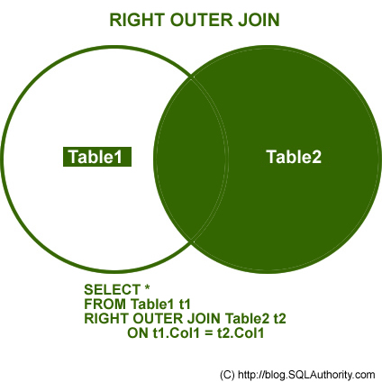

```r
dt1[dt2, on='EXMD_BZ_YYYY']
```

```
##    EXMD_BZ_YYYY RN_INDI HME_YYYYMM Q_PHX_DX_STK Q_PHX_DX_HTDZ Q_PHX_DX_HTN
## 1:         2010  752067     201007            0             0            0
## 2:         2011  694083     201103           NA            NA           NA
## 3:         2012  699142     201210           NA            NA           NA
## 4:         2014      NA         NA           NA            NA           NA
## 5:         2015      NA         NA           NA            NA           NA
##    Q_PHX_DX_DM Q_PHX_DX_DLD Q_PHX_DX_PTB Q_HBV_AG Q_SMK_YN Q_DRK_FRQ_V09N HGHT
## 1:           0            0            0        2        1              1  167
## 2:          NA           NA           NA        2        1              0  156
## 3:          NA           NA           NA        2        1              0  162
## 4:          NA           NA           NA       NA       NA             NA   NA
## 5:          NA           NA           NA       NA       NA             NA   NA
##    WGHT WSTC  BMI VA_LT VA_RT BP_SYS BP_DIA URN_PROT  HGB FBS TOT_CHOL TG HDL
## 1:   71   88 25.5   1.0   1.5    116     72        1 13.7  91      207 76  49
## 2:   64   87 26.3   0.3   0.4    136     60        1 14.0  82      195 99  51
```

[output cut: 33 more lines]

```r
# same
merge(dt1, dt2, by='EXMD_BZ_YYYY', all.y=T)
```

```
##    EXMD_BZ_YYYY RN_INDI.x HME_YYYYMM.x Q_PHX_DX_STK.x Q_PHX_DX_HTDZ.x
## 1:         2010    752067       201007              0               0
## 2:         2011    694083       201103             NA              NA
## 3:         2012    699142       201210             NA              NA
## 4:         2014        NA           NA             NA              NA
## 5:         2015        NA           NA             NA              NA
##    Q_PHX_DX_HTN.x Q_PHX_DX_DM.x Q_PHX_DX_DLD.x Q_PHX_DX_PTB.x Q_HBV_AG.x
## 1:              0             0              0              0          2
## 2:             NA            NA             NA             NA          2
## 3:             NA            NA             NA             NA          2
## 4:             NA            NA             NA             NA         NA
## 5:             NA            NA             NA             NA         NA
##    Q_SMK_YN.x Q_DRK_FRQ_V09N.x HGHT.x WGHT.x WSTC.x BMI.x VA_LT.x VA_RT.x
## 1:          1                1    167     71     88  25.5     1.0     1.5
## 2:          1                0    156     64     87  26.3     0.3     0.4
```

[output cut: 39 more lines]

### **4. full_outer_join**

어느 한 쪽에 존재하는 경우 **merge(dt1, dt2, by=‘key’, all=T)** 형식 사용

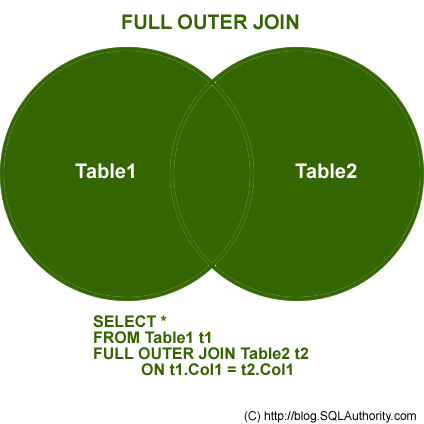

```r
merge(dt1, dt2, by='EXMD_BZ_YYYY', all=TRUE)
```

```
##    EXMD_BZ_YYYY RN_INDI.x HME_YYYYMM.x Q_PHX_DX_STK.x Q_PHX_DX_HTDZ.x
## 1:         2009    825387       200904              0               0
## 2:         2010    752067       201007              0               0
## 3:         2011    694083       201103             NA              NA
## 4:         2012    699142       201210             NA              NA
## 5:         2013    203606       201307              0               0
## 6:         2014        NA           NA             NA              NA
## 7:         2015        NA           NA             NA              NA
##    Q_PHX_DX_HTN.x Q_PHX_DX_DM.x Q_PHX_DX_DLD.x Q_PHX_DX_PTB.x Q_HBV_AG.x
## 1:              0             0              0             NA         NA
## 2:              0             0              0              0          2
## 3:             NA            NA             NA             NA          2
## 4:             NA            NA             NA             NA          2
## 5:              0             0              0              0          2
## 6:             NA            NA             NA             NA         NA
```

[output cut: 57 more lines]

## 데이터 테이블 수정 연산자 :=

데이터 테이블에서 열 j를 추가하거나 갱신 또는 삭제할 때 특수부호 **:=** 연산자를 사용한다. 수정 또는 생성할 열이 하나인 경우, **dt[ , newcol1 := ]** 형식을 쓰며 열이 두 개 이상인 경우 **dt[, ‘:=’ (col1=, col2=)]**을 사용한다.

다음의 예시를 통해서 자세히 알아보자.

기존의 데이터 테이블에서 HDL - LDL을 구해서 diff라는 이름의 열을 새로 생성한다. 그리고, HGHT와 WGHT는 HGHT*0.9, WGHT+0.5로 수정한다.

### **열 생성/수정**

```r
# 열 생성
dt[, diff := HDL-LDL]

# 열 수정
dt[, ':=' (HGHT = HGHT*0.9, WGHT = WGHT+0.5)]
```

위 코드를 실행시키면 갱신이 눈에 보이지 않는 상태로 실행되며, 만약 갱신 결과를 눈에 보이도록 출력하려면 제일 뒤에 [] 를 붙여주어야 한다.

```r
# 열 생성
dt[, diff := HDL-LDL][]
```

```
##       EXMD_BZ_YYYY RN_INDI HME_YYYYMM Q_PHX_DX_STK Q_PHX_DX_HTDZ Q_PHX_DX_HTN
##    1:         2009  825387     200904            0             0            0
##    2:         2009  418137     200901            0             0            0
##    3:         2009  948405     200906            0             0            0
##    4:         2009  701404     200909           NA            NA           NA
##    5:         2009   79250     200901            0             0            0
##   ---
## 1640:         2015    4263     201512            0             0            0
## 1641:         2015  128799     201503           NA            NA           NA
## 1642:         2015  302146     201511            0             0            0
## 1643:         2015  798472     201507           NA            NA           NA
## 1644:         2015  127519     201511            0             0            1
##       Q_PHX_DX_DM Q_PHX_DX_DLD Q_PHX_DX_PTB Q_HBV_AG Q_SMK_YN Q_DRK_FRQ_V09N
##    1:           0            0           NA       NA        1              1
##    2:           0            0           NA       NA        2             NA
```

[output cut: 33 more lines]

```r
# 열 수정
dt[, ':=' (HGHT = HGHT*0.9, WGHT = WGHT+0.5)][]
```

```
##       EXMD_BZ_YYYY RN_INDI HME_YYYYMM Q_PHX_DX_STK Q_PHX_DX_HTDZ Q_PHX_DX_HTN
##    1:         2009  825387     200904            0             0            0
##    2:         2009  418137     200901            0             0            0
##    3:         2009  948405     200906            0             0            0
##    4:         2009  701404     200909           NA            NA           NA
##    5:         2009   79250     200901            0             0            0
##   ---
## 1640:         2015    4263     201512            0             0            0
## 1641:         2015  128799     201503           NA            NA           NA
## 1642:         2015  302146     201511            0             0            0
## 1643:         2015  798472     201507           NA            NA           NA
## 1644:         2015  127519     201511            0             0            1
##       Q_PHX_DX_DM Q_PHX_DX_DLD Q_PHX_DX_PTB Q_HBV_AG Q_SMK_YN Q_DRK_FRQ_V09N
##    1:           0            0           NA       NA        1              1
##    2:           0            0           NA       NA        2             NA
```

[output cut: 33 more lines]

### **열 삭제**

데이터 테이블에서 열을 삭제하려면 **col := NULL** 형식을 사용한다.

```r
# BMI 삭제
dt[, BMI := NULL]
```

## 특수 기호

### **.SD**

**.SD** 는 ’Subset of Data’의 약자로, by로 지정한 그룹 칼럼을 제외한 모든 칼럼을 대상으로 연산을 수행할 때 사용한다.

```r
# 모든 칼럼의 연도별 평균값
dt[, lapply(.SD, mean), by=EXMD_BZ_YYYY]
```

```
##    EXMD_BZ_YYYY  RN_INDI HME_YYYYMM Q_PHX_DX_STK Q_PHX_DX_HTDZ Q_PHX_DX_HTN
## 1:         2009 499606.8   200908.2           NA            NA           NA
## 2:         2010 472277.1   201007.6           NA            NA           NA
## 3:         2011 510926.9   201107.8           NA            NA           NA
## 4:         2012 490263.9   201207.8           NA            NA           NA
## 5:         2013 483700.7   201308.1           NA            NA           NA
## 6:         2014 489703.6   201407.9           NA            NA           NA
## 7:         2015 491209.6   201508.7           NA            NA           NA
##    Q_PHX_DX_DM Q_PHX_DX_DLD Q_PHX_DX_PTB Q_HBV_AG Q_SMK_YN Q_DRK_FRQ_V09N
## 1:          NA           NA           NA       NA       NA             NA
## 2:          NA           NA           NA 2.326271 1.703390      1.0423729
## 3:          NA           NA           NA 2.233184 1.587444      1.0493274
## 4:          NA           NA           NA 2.213675 1.598291      0.9786325
## 5:          NA           NA           NA 2.226337 1.695473             NA
## 6:          NA           NA           NA 2.185039 1.614173             NA
```

[output cut: 25 more lines]

### **.SDcols**

**.SDcols**는 연산 대상이 되는 특정 칼럼을 지정하는 특수 부호이다. 특정 열을 대상으로 연산을 할 때 by 다음에 **.SDcols = c(“col1”, “col2”, …)**로 연산 대상을 지정한다.

```r
# HGHT, WGHT 칼럼의 연도별 평균값
dt[, lapply(.SD, mean), by=EXMD_BZ_YYYY, .SDcols=c("HGHT", "WGHT")]
```

```
##    EXMD_BZ_YYYY     HGHT     WGHT
## 1:         2009 132.9081 65.32710
## 2:         2010 133.5917 66.13983
## 3:         2011 132.9599 65.89686
## 4:         2012 133.5842 66.82051
## 5:         2013 133.5767 65.90535
## 6:         2014 133.0983 65.47244
## 7:         2015 133.2281 67.07500
```

### **.N**

**.N**는 부분 데이터의 행의 수를 나타내며, 요약 통계치를 구할 때 대상 데이터의 수를 간편하게 구할 수 있다.

```r
# HGHT, WGHT 칼럼의 연도별 평균값과 행의 수
dt[, c(.N, lapply(.SD, mean)), by=EXMD_BZ_YYYY, .SDcols=c("HGHT", "WGHT")]
```

```
##    EXMD_BZ_YYYY   N     HGHT     WGHT
## 1:         2009 214 132.9081 65.32710
## 2:         2010 236 133.5917 66.13983
## 3:         2011 223 132.9599 65.89686
## 4:         2012 234 133.5842 66.82051
## 5:         2013 243 133.5767 65.90535
## 6:         2014 254 133.0983 65.47244
## 7:         2015 240 133.2281 67.07500
```

## 데이터 재구조화 melt & dcast

마지막으로 효율적으로 data의 형태를 바꾸는 `melt`(wide to long)와 `dcast`(long to wide) 를 알아보겠다. `melt` 함수는 데이터 테이블을 녹여서 넓은 자료구조를 길게 재구조화하며, `dcast` 함수는 데이터 테이블을 주조하여 긴 자료구조를 넓게 재구조화한다.

### **melt**

`melt` 함수는 일부 고정 칼럼을 제외한 나머지 칼럼을 stack 처리할 수 있다. **melt(data, id.vars, measure.vars, variable.name, value.name)** 형식으로 쓰이며, id.vars에는 고정 칼럼을 measure.vars는 stack 처리할 칼럼을 넣는다. `melt`함수를 써서 길게 재구조화한 후의 “variable”, “value” 변수 이름을 바꾸고 싶다면 variable.name=“new_var_name”, value.name=“new_val_name” 처럼 새로운 칼럼 이름을 부여하여 지정할 수 있다.

```r
# wide to long
dt.long1 <- melt(dt,
                id.vars = c("EXMD_BZ_YYYY", "RN_INDI", "HGHT", "WGHT"),
                measure.vars = c("TOT_CHOL", "HDL", "LDL"),
                variable.name = "measure",
                value.name = "val")
head(dt.long1)
```

```
##    EXMD_BZ_YYYY RN_INDI   HGHT WGHT  measure val
## 1:         2009  825387 134.46   71 TOT_CHOL 193
## 2:         2009  418137 142.56   65 TOT_CHOL 137
## 3:         2009  948405 133.65   51 TOT_CHOL 159
## 4:         2009  701404 126.36   62 TOT_CHOL 237
## 5:         2009   79250 114.21   41 TOT_CHOL 160
## 6:         2009  714509 137.70   70 TOT_CHOL 126
```

##### **Enhanced melt**

`melt` 함수는 동시에 여러 개의 칼럼들을 묶어서 사용할 수도 있다.

1. **list**에 복수의 칼럼 이름을 입력하는 방법

`melt` 함수에 **measure=list(col1, col2, …)** 형식으로 여러 개의 칼럼 이름을 list() 형태로 넣는다. 이때 공통의 value.name을 지정할 수 있다.

```r
col1 <- c("BP_SYS", "BP_DIA")
col2 <- c("HDL", "LDL")

dt.long2 <- melt(dt,
                 measure = list(col1, col2),
                 value.name = c("BP", "Chol"))
head(dt.long2)
```

```
##    EXMD_BZ_YYYY RN_INDI HME_YYYYMM Q_PHX_DX_STK Q_PHX_DX_HTDZ Q_PHX_DX_HTN
## 1:         2009  825387     200904            0             0            0
## 2:         2009  418137     200901            0             0            0
## 3:         2009  948405     200906            0             0            0
## 4:         2009  701404     200909           NA            NA           NA
## 5:         2009   79250     200901            0             0            0
## 6:         2009  714509     200907           NA            NA           NA
##    Q_PHX_DX_DM Q_PHX_DX_DLD Q_PHX_DX_PTB Q_HBV_AG Q_SMK_YN Q_DRK_FRQ_V09N
## 1:           0            0           NA       NA        1              1
## 2:           0            0           NA       NA        2             NA
## 3:           0            0           NA        1        1              0
## 4:          NA           NA           NA        1        1              0
## 5:           0            0           NA        1        1              0
## 6:          NA           NA           NA        1        1              0
##      HGHT WGHT WSTC VA_LT VA_RT URN_PROT  HGB FBS TOT_CHOL  TG CRTN SGOT SGPT
## 1: 134.46   71   85   0.9   1.0        1 14.8 101      193 120  1.0   23   23
## 2: 142.56   65   80   0.7   0.6        1 16.8  75      137  54  0.9   17   15
## 3: 133.65   51   70   0.5   0.5        1 12.6  88      159  59  0.9   19   16
## 4: 126.36   62   77   1.0   0.9        1 13.1  86      237  84  0.7   31   20
## 5: 114.21   41   69   0.1   0.7        1 11.8  86      160 144  0.6   14   16
## 6: 137.70   70   81   1.5   1.2        1 14.4  89      126  35  1.0   50   79
##    GGT GFR diff variable  BP Chol
## 1:  18 101  -79        1 130   45
## 2:  17 105  -30        1 100   48
## 3:  18  68  -29        1 110   59
## 4:  12  88 -142        1 107   39
## 5:  11  59  -57        1 100   37
## 6:  21 113   47        1 108   83
```

2. 특정 패턴을 **정규 표현식**으로 매칭하는 방법

`melt` 함수에 **measure=patterns()** 형식으로 특정 패턴을 따르는 복수의 칼럼을 정규 표현식을 통해 설정한다.

```r
dt.long3 <- melt(dt,
            measure=patterns("^Q_PHX_DX", "^BP"),
            value.name=c("Q_PHX_DX", "BP"))
head(dt.long3)
```

```
##    EXMD_BZ_YYYY RN_INDI HME_YYYYMM Q_HBV_AG Q_SMK_YN Q_DRK_FRQ_V09N   HGHT WGHT
## 1:         2009  825387     200904       NA        1              1 134.46   71
## 2:         2009  418137     200901       NA        2             NA 142.56   65
## 3:         2009  948405     200906        1        1              0 133.65   51
## 4:         2009  701404     200909        1        1              0 126.36   62
## 5:         2009   79250     200901        1        1              0 114.21   41
## 6:         2009  714509     200907        1        1              0 137.70   70
##    WSTC VA_LT VA_RT URN_PROT  HGB FBS TOT_CHOL  TG HDL LDL CRTN SGOT SGPT GGT
## 1:   85   0.9   1.0        1 14.8 101      193 120  45 124  1.0   23   23  18
## 2:   80   0.7   0.6        1 16.8  75      137  54  48  78  0.9   17   15  17
## 3:   70   0.5   0.5        1 12.6  88      159  59  59  88  0.9   19   16  18
## 4:   77   1.0   0.9        1 13.1  86      237  84  39 181  0.7   31   20  12
## 5:   69   0.1   0.7        1 11.8  86      160 144  37  94  0.6   14   16  11
## 6:   81   1.5   1.2        1 14.4  89      126  35  83  36  1.0   50   79  21
##    GFR diff variable Q_PHX_DX  BP
## 1: 101  -79        1        0 130
## 2: 105  -30        1        0 100
## 3:  68  -29        1        0 110
## 4:  88 -142        1       NA 107
## 5:  59  -57        1        0 100
## 6: 113   47        1       NA 108
```

### **dcast**

`dcast` 함수는 `melt` 함수를 통해 길게 쌓여진 칼럼을 각 항목별로 분리하기 위해 사용한다. **dcast(data, formula, value.var, fun.aggregate)** 형식으로 쓰이며, formula의 LHS에는 id.vars, RHS에는 variable을 입력하고 value.name에는 “value”를 입력한다. 이때 “variable”과 “value” 변수 이름을 바꿨다면, 새로 지정한 칼럼명을 넣는다.

```r
# long to wide
dt.wide1 <- dcast(dt.long1, EXMD_BZ_YYYY + RN_INDI + HGHT + WGHT ~ measure, value.var = "val")
head(dt.wide1)
```

```
##    EXMD_BZ_YYYY RN_INDI   HGHT WGHT TOT_CHOL HDL LDL
## 1:         2009    4263 141.75   67      264  81 172
## 2:         2009    4664 129.60   54      192  57 120
## 3:         2009    9866 127.98   77      112  48  40
## 4:         2009   17079 136.89   55      161  72  78
## 5:         2009   26776 139.32   79      189  59 117
## 6:         2009   27226 120.69   57      206 101  96
```

`dcast` 함수에 집계 함수(fun.aggregate)를 사용하여 그룹별 요약 통계량을 계산한 결과를 재구조화하여 반환할 수 있다.

```r
# 연도별 TOT_CHOL, HDL, LDL의 평균값
dt.wide2 <- dcast(dt.long1, EXMD_BZ_YYYY ~ measure, value.var = "val", fun.aggregate = mean, na.rm =T)
head(dt.wide2)
```

```
##    EXMD_BZ_YYYY TOT_CHOL      HDL      LDL
## 1:         2009 195.0748 55.61215 150.9486
## 2:         2010 194.7669 55.15678 112.9914
## 3:         2011 194.1076 57.31390 112.9450
## 4:         2012 198.6154 55.94872 117.5259
## 5:         2013 192.1193 55.46091 111.1577
## 6:         2014 194.9646 55.64173 116.5455
```

##### **Enhanced dcast**

`dcast` 함수의 value.vars에 복수의 칼럼을 넣어 여러 개의 칼럼을 동시에 재구조화할 수 있다.

```r
# 연도별 TOT_CHOL, HDL, LDL의 평균값
dt.wide3 <- dcast(dt.long2,
                  ... ~ variable,
                  value.var = c("BP", "Chol"))
head(dt.wide3)
```

```
##    EXMD_BZ_YYYY RN_INDI HME_YYYYMM Q_PHX_DX_STK Q_PHX_DX_HTDZ Q_PHX_DX_HTN
## 1:         2009    4263     200910           NA            NA           NA
## 2:         2009    4664     200910            0             0            0
## 3:         2009    9866     200912           NA            NA           NA
## 4:         2009   17079     200911            0             0            0
## 5:         2009   26776     200902           NA            NA           NA
## 6:         2009   27226     200908            0             0            0
##    Q_PHX_DX_DM Q_PHX_DX_DLD Q_PHX_DX_PTB Q_HBV_AG Q_SMK_YN Q_DRK_FRQ_V09N
## 1:          NA           NA           NA        2        2              1
## 2:           0            0           NA        2        1              0
## 3:          NA           NA           NA        3        1              0
## 4:           0            0           NA        2        1              2
## 5:          NA           NA           NA        2        2              2
## 6:           0            0           NA        2        1              0
##      HGHT WGHT WSTC VA_LT VA_RT URN_PROT  HGB FBS TOT_CHOL  TG CRTN SGOT SGPT
## 1: 141.75   67   78   1.5   2.0        1 13.5  79      264  54  1.2   15   15
## 2: 129.60   54   63   0.9   0.9        1 12.7  84      192  74  0.9   17    9
## 3: 127.98   77   82   1.0   0.5        1 12.0 101      112 116  0.7   21   24
## 4: 136.89   55   67   1.0   0.8        2 13.8  78      161  52  1.0   12    9
## 5: 139.32   79   86   0.8   1.0        1 15.6  86      189  62  0.9   19   16
## 6: 120.69   57   73   1.2   1.2        1 12.7  77      206  44  0.6   16   10
##    GGT GFR diff BP_1 BP_2 Chol_1 Chol_2
## 1:  17  77  -91  110   70     81    172
## 2:   9  70  -63  110   80     57    120
## 3:  20 133    8  121   63     48     40
## 4:  17  72   -6  106   60     72     78
## 5:  44 111  -58  118   73     59    117
## 6:  15 106    5  103   65    101     96
```